# Lab 1: The Local Baseline

Manual Landsat 8 Processing in ArcGIS Pro

Author

Dr. Francisco Laso, ESCI 442/542 — Introduction to Remote Sensing

Lab 1 Module I — The Local Baseline

**Readings due before lab:** Campbell Ch. 1 — Introducing Remote Sensing Basics (pp. 3–23) | Ch. 2 — Electromagnetic Radiation (pp. 24–53)

## Background

On the night of September 7, 2020, the Labor Day windstorm tore through the Cascades and eastern foothills of Washington State. Within 24 hours, more than 300,000 acres burned — the most destructive fire event in Washington’s recorded history. The Babb, Pearl Hill, and Cold Springs fires merged and exploded across the landscape at speeds that outpaced every evacuation route.

From the ground, the devastation was chaotic. From space, it was remarkably legible.

That contrast — the difference between what a human witness sees and what a sensor records — is the core insight of this course. This week you will work with a Landsat image of the burn scar acquired in the weeks after the fires. You will download the data yourself, manually assemble band combinations in ArcGIS Pro, and read pixel values directly from the image. Every step is intentionally hands-on and procedurally explicit.

Why start here, before Google Earth Engine? Because understanding *what* GEE is doing on your behalf later requires having done it by hand first. By the end of this lab you will understand why a pixel glows red in one composite and is nearly invisible in another — and you will be able to trace that difference back to the physics you read about in Campbell Chapters 1 and 2.

**Note**

**Lab Objectives**

By the end of this lab you will be able to:

1. Locate, filter, and download a Landsat 8 Level-2 scene from USGS EarthExplorer
2. Understand the file structure of a Landsat product (individual band files, QA layers, MTL metadata)
3. Load raster bands and create composites in ArcGIS Pro
4. Interpret natural color, NIR false color, and SWIR composites in the context of the electromagnetic spectrum
5. Use the Identify tool and Spectral Signature Viewer to read and compare pixel reflectance values across cover types
6. Produce a cartographically complete map layout and export it to PDF

**Warning**

**Before You Begin**

Make sure you have:

- Completed the Campbell Ch. 1 and Ch. 2 readings
- Created a free USGS EarthExplorer account at earthexplorer.usgs.gov
- Opened ArcGIS Pro (available on all lab computers in AH 016, or via your personal license)
- At least 2 GB of free disk space for the downloaded image data

## Part 0 — ArcGIS Pro Orientation

**Tip**

**New to ArcGIS Pro?** This section is for you. If you have used ArcGIS Pro before, read through it quickly — a few interface details differ from ArcMap — then continue to Part 1.

**Note**

**ArcGIS Pro Learning Resources**

If you want more background before or after this lab, these free official resources are the best starting point:

- **[Introduction to ArcGIS Pro](https://pro.arcgis.com/en/pro-app/latest/get-started/get-started.htm)** — Official documentation covering the interface, projects, and basic workflows
- **[Get Started with ArcGIS Pro](https://learn.arcgis.com/en/projects/get-started-with-arcgis-pro/)** — Hands-on guided tutorial from Esri Learn (free, ~1 hour)
- **[ArcGIS Pro Quick-Start Tutorials](https://pro.arcgis.com/en/pro-app/latest/get-started/pro-quickstart-tutorials.htm)** — Short focused lessons on specific tasks (mapping, editing, sharing)
- **[ArcGIS Pro Resources Hub](https://www.esri.com/en-us/arcgis/products/arcgis-pro/resources)** — Videos, blog posts, and community forums

ArcGIS Pro is a desktop GIS application made by Esri. Unlike web-based tools, it runs locally on your computer and gives you direct, hands-on control over data files. This is both its strength and its limitation — you have complete flexibility, but you are responsible for managing your own files.

### The ArcGIS Pro Interface

When you first open ArcGIS Pro and create a new project, you will see four main areas:

**1. The Map View (center)** — This is your canvas. Spatial data you add will appear here. You can pan by clicking and dragging, zoom with the scroll wheel, and right-click for context options.

**2. The Contents Pane (left)** — Lists all layers currently in your map, in display order. Layers at the top of the list draw on top of layers below. You control visibility (eye icon), layer order (drag), and symbology (double-click the color swatch) from here.

**3. The Catalog Pane (right)** — Your file browser. Connects to folders, databases, and online sources. You can drag data directly from here into the Map View.

**4. The Ribbon (top)** — Tabbed menu of tools organized by task. The **Map** tab has navigation tools; the **Analysis** tab has geoprocessing; the **Insert** tab lets you add map layouts.

[figure not shown]

The ArcGIS Pro interface showing the four main areas: Map View (center), Contents Pane (left), Catalog Pane (right), and the Ribbon (top). Your screen will look similar to this after creating a new project.

### Creating a New Project

1. Open ArcGIS Pro → click **New** → select **Map**
2. Name your project `Lab01_YourLastName` and save it to your designated course folder (e.g., `H:\ESCI442\Lab01\`)
3. ArcGIS Pro creates a project folder containing a `.aprx` project file along with default geodatabase and toolbox files — do not rename or move these

**Warning**

**File management matters.** ArcGIS Pro projects link to data by file path. If you move your data after adding it to a project, the links break and your layers will show a red exclamation mark. Keep all your data inside your Lab01 project folder from the start.

### Adding Raster Data

To add a raster (image) file: in the **Catalog Pane**, navigate to the folder containing your file → right-click the file → **Add to Current Map**. Or drag it directly into the Map View.

You can also use the menu: **Map tab → Add Data** (the yellow plus icon).

### The Coordinate System

Before working with spatial data, always check your map’s coordinate system. Right-click the **Map** entry at the top of the Contents Pane → **Properties** → **Coordinate System**. This shows the projection currently in use. ArcGIS Pro will often auto-assign a coordinate system based on the first layer you add — this is usually correct but always worth confirming.

## Part 1 — Data Acquisition

The data you will use in this lab is **Landsat 8 OLI Level-2 Surface Reflectance** from the USGS Landsat archive. “Level-2” means the raw satellite signal has already been converted to surface reflectance — a physically meaningful quantity that represents the proportion of incoming solar radiation reflected by the ground surface. You will read more about radiance versus reflectance in Campbell Ch. 2; for now, understand that surface reflectance is the standard for scientific analysis because it allows meaningful comparisons across dates, sensors, and locations.

### Step 1.1 — Log Into EarthExplorer

Navigate to earthexplorer.usgs.gov and log in. If you do not yet have an account, click **Register** and create one — it is free and takes about two minutes.

### Step 1.2 — Define Your Search Area

You will search for imagery over the **Pearl Hill Fire** burn scar, located in Douglas and Okanogan Counties in north-central Washington State.

In the **Search Criteria** tab (left panel):

1. Click the **Address/Place** tab within the search box
2. Type: `Coulee City, Washington` and click **Show**
3. The map will center near Coulee City, which sits close to the southern edge of the Pearl Hill burn perimeter.
4. Then click the **Coordinates** tab and enter the following bounding box in decimal degrees (type the numbers exactly as shown — no degree symbols needed):

| Corner | Latitude | Longitude |
| --- | --- | --- |
| Upper Left | 47.95 | -119.80 |
| Lower Right | 47.45 | -119.10 |

**Tip**

**Tip:** You can also navigate the EarthExplorer map manually — zoom in to north-central Washington and use the polygon or circle drawing tool to define your area of interest visually.

### Step 1.3 — Set the Date Range

In the **Date Range** fields, enter:

- **Start Date:** 09/20/2020
- **End Date:** 11/15/2020

This window captures imagery after the fires were contained (early September) but before significant snow cover. You want to see the burn scar clearly, not smoke or clouds.

### Step 1.4 — Select the Dataset

Click **Data Sets >>** to advance to the dataset selection panel.

Expand the following tree: **Landsat → Landsat Collection 2 Level-2**

Check the box for **Landsat 8-9 OLI/TIRS C2 L2**

Then click **Results >>**.

### Step 1.5 — Evaluate and Download a Scene

EarthExplorer will return thumbnail images of available scenes. You are looking for a scene that:

- Covers the fire area (the burn scar appears as a large reddish-brown area east of the Cascades ridge in the browse thumbnail)
- Has low cloud cover (aim for < 15%)
- Was acquired in October or early November 2020

The scene you are looking for is on **WRS-2 Path 045, Row 027** — this is the orbital grid cell that covers the Pearl Hill burn area. If results seem to show the wrong location, confirm this path/row is represented in your results.

You may find either a **Landsat 8** (LC08) or **Landsat 9** (LC09) scene — both are acceptable for this lab. The band structure and file naming convention are identical between the two sensors.

Select the **Product Bundle** option — this downloads all bands plus metadata as a single compressed `.tar` file (approximately 1–2 GB).

**Note**

**What is inside a Landsat Product Bundle?**

When you unzip the downloaded `.tar` file, you will find individual `.TIF` files for each spectral band, named using this convention:

`LC08_L2SP_045027_20201003_20201016_02_T1_SR_B2.TIF`

- `LC08` = Landsat 8 (or `LC09` for Landsat 9)
- `045027` = path/row (WRS-2 orbit grid location — Path 045, Row 027)
- `20201003` = acquisition date (October 3, 2020)
- `SR_B2` = Surface Reflectance, Band 2

The band files you will use most in this lab:

| File Suffix | Band Name | Wavelength | Color |
| --- | --- | --- | --- |
| `SR_B2` | Blue | 0.45–0.51 µm | Blue |
| `SR_B3` | Green | 0.53–0.59 µm | Green |
| `SR_B4` | Red | 0.64–0.67 µm | Red |
| `SR_B5` | NIR | 0.85–0.88 µm | Near-Infrared |
| `SR_B6` | SWIR 1 | 1.57–1.65 µm | Shortwave Infrared |
| `SR_B7` | SWIR 2 | 2.11–2.29 µm | Shortwave Infrared |

The `QA_PIXEL` file encodes cloud and cloud-shadow masks — you will encounter it again in later labs. The `MTL.txt` file is the metadata record for the scene.

### Step 1.6 — Extract the Files

Use 7-Zip, WinRAR, or Windows’ built-in extraction to unzip the `.tar` file. Place the extracted folder inside your `Lab01` project directory, e.g.:

`H:\ESCI442\Lab01\LC08_L2SP_045027_20201003\`

**Warning**

**Do not move individual band files out of this folder.** Keep them together. Landsat band files are designed to be used as a set.

> **📸 Screenshot 1:** Take a screenshot of EarthExplorer showing your selected scene’s thumbnail overlaid on the map, with the scene metadata (path/row, date, cloud cover) visible in the results panel. Include this in your lab submission.

## Part 2 — Loading Data in ArcGIS Pro

### Step 2.1 — Create a Composite Raster

Rather than loading six individual band files separately, you will combine them into a single multi-band composite using the **Composite Bands** geoprocessing tool. This creates one `.TIF` file containing all bands in order — easier to work with and the required input for the Spectral Profile chart later.

1. In the ArcGIS Pro ribbon, go to **Analysis tab → Tools** (opens the Geoprocessing pane)
2. In the search bar, type `Composite Bands` and click the result
3. In the **Input Rasters** field, add the bands **in this order:** `SR_B2, SR_B3, SR_B4, SR_B5, SR_B6, SR_B7` (Blue, Green, Red, NIR, SWIR1, SWIR2)
4. Set the **Output Raster** location to your Lab01 folder and name it `L8_composite_6band.TIF`
5. Click **Run**

When complete, right-click the output in the Catalog Pane → **Add to Current Map**.

**Tip**

**Why this band order?** Convention matters. Loading bands in this order (Blue through SWIR2) means Band 1 in your composite = Blue, Band 2 = Green, Band 3 = Red, Band 4 = NIR, Band 5 = SWIR1, Band 6 = SWIR2. When you set display combinations, you will reference these band numbers. Keeping them in spectral order avoids confusion.

### Step 2.2 — Initial Display and Coordinate System

When the composite loads, ArcGIS Pro will likely display it as a grayscale image or with an automatic stretch. Before adjusting the display:

1. Right-click **Map** at the top of the Contents Pane → **Properties → Coordinate System**
2. Note the coordinate system. Landsat 8 data is delivered in **UTM (Universal Transverse Mercator)**, projected using the WGS 84 datum. Your scene is in **UTM Zone 10N**.
3. Click **OK**

**Note**

**Why UTM?** Landsat imagery is projected in UTM because it minimizes distortion over the relatively small area of a single scene (~185 × 185 km). UTM preserves shape and area well at this scale, making pixel sizes consistent and measurements reliable. The WGS 84 datum is the standard reference ellipsoid used by most modern remote sensing and GPS systems. Your scene’s coordinate system should read **WGS 1984 UTM Zone 10N** (EPSG/WKID: 32610) in the Layer Properties dialog — exactly matching what you see in the Source → Spatial Reference panel.

> **📸 Screenshot 2:** Take a screenshot of ArcGIS Pro with your 6-band composite loaded and the coordinate system properties dialog open, showing the UTM Zone 10N projection. Your screenshot should look similar to the example below.

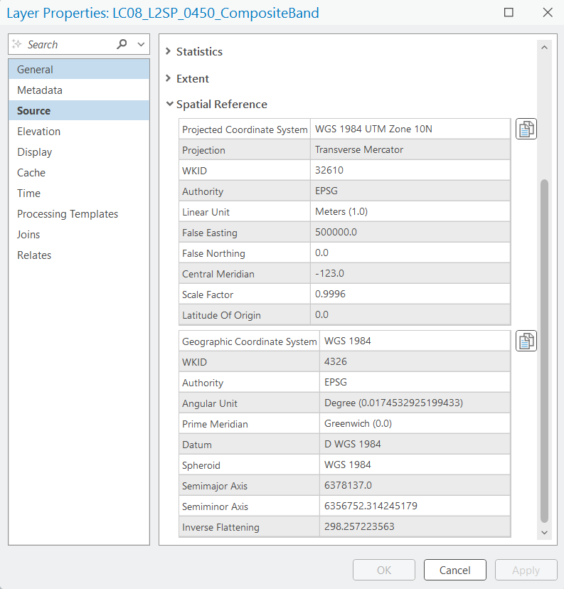

Example of the Layer Properties dialog showing the spatial reference for the Landsat 8 composite. Verify that your scene shows **WGS 1984 UTM Zone 10N** (WKID 32610).

## Part 3 — Band Combinations and Visual Interpretation

This is the conceptual core of the lab. A satellite image is not a photograph — it is a set of independent measurements of reflected energy at different wavelengths. By choosing which wavelength measurements to display as Red, Green, and Blue on your screen, you create a *composite image* that emphasizes different surface properties.

Your eye never sees NIR radiation. But by mapping NIR reflectance to the red channel on your monitor, you can make the invisible visible.

**Warning**

**Band numbering in your composite vs. original Landsat bands**

Because you built your composite from Landsat bands B2 through B7 (skipping B1), ArcGIS Pro renumbers them internally starting from 1. When setting band combinations below, always use the **composite band number** (1–6), not the original Landsat band number:

| Composite Band | Original Landsat Band | Wavelength | Region |
| --- | --- | --- | --- |
| 1 | B2 | 0.48 µm | Blue |
| 2 | B3 | 0.56 µm | Green |
| 3 | B4 | 0.65 µm | Red |
| 4 | B5 | 0.86 µm | NIR |
| 5 | B6 | 1.61 µm | SWIR 1 |
| 6 | B7 | 2.20 µm | SWIR 2 |

Keep this table handy — you will reference it throughout Parts 3 and 4.

### Step 3.1 — Natural Color Composite (Composite Bands 3-2-1 as R-G-B)

This composite approximates what your eye would see from an airplane.

1. In the **Contents Pane**, double-click the color swatch (thumbnail) of your composite layer to open the **Symbology Pane**
2. Change **Symbology Type** to **RGB**
3. Set:
   - **Red channel → Band 3** (this is Landsat B4, Red, 0.64–0.67 µm)
   - **Green channel → Band 2** (this is Landsat B3, Green, 0.53–0.59 µm)
   - **Blue channel → Band 1** (this is Landsat B2, Blue, 0.45–0.51 µm)
4. Under **Stretch Type**, select **Percent Clip**. Two fields will appear for **Min** and **Max**. The right value depends on which composite you are displaying:
   - For **natural color** (visible bands): start with **Min: 0.5, Max: 0.5**
   - For **NIR and SWIR composites**: use **Min: 0.2, Max: 0.2** — the NIR band has a much wider dynamic range and aggressive clipping will blow out bright surfaces to pure white

   Adjust visually if needed — the goal is an image where you can distinguish detail in both bright and dark areas without either clipping to solid white or solid black.

**Tip**

**Why different values for different composites?** Landsat Level-2 surface reflectance values are stored as scaled integers. The NIR band in particular has a very wide range of values — healthy vegetation reflects extremely strongly in NIR compared to water or burned surfaces. A 2% clip cuts too aggressively into this range and saturates the bright vegetation to white, destroying the contrast you are trying to see. Starting at 0.2% and adjusting is safer for NIR-containing composites.

5. Click anywhere outside the pane to apply

Zoom into the burn scar area (northeast of the Cascades ridge). The burn scar appears as a pale gray to whitish area in the upper right of the scene — subtle in natural color, which is intentional. Keep this view in mind as you move to the next composite.

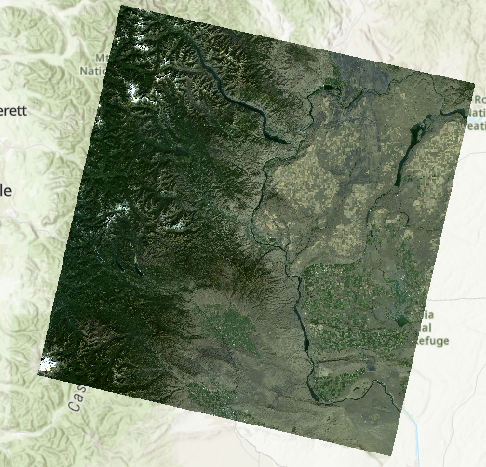

Natural color composite (composite bands 3-2-1). The burn scar is the pale gray area in the upper right. Forest appears dark green; water appears very dark. The scar is difficult to delineate precisely in this view.

**Note**

> **❓ Question 1 (Interpretation):** Examine the natural color composite. Identify and describe three distinct land cover types you can visually distinguish in the image (e.g., the burn scar, agricultural fields, water). For each, describe its color and suggest a reason, based on Campbell Ch. 2’s discussion of spectral response, why that surface looks the way it does in visible wavelengths.

### Step 3.2 — NIR False Color Composite (Composite Bands 4-3-2 as R-G-B)

Now you will display the near-infrared band in the red channel of your monitor.

1. Return to the **Symbology Pane**
2. Set:
   - **Red channel → Band 4** (this is Landsat B5, NIR, 0.85–0.88 µm)
   - **Green channel → Band 3** (this is Landsat B4, Red, 0.64–0.67 µm)
   - **Blue channel → Band 2** (this is Landsat B3, Green, 0.53–0.59 µm)
3. Keep Stretch Type set to Percent Clip — adjust Min/Max visually as needed (0.2–1.0 is a typical range for this data)

Healthy vegetation will now appear in **bright red**. The dense Cascades forests on the western side of the scene will be the most intensely red areas. The burn scar will appear as a large **dusky pink to muted brownish-pink area** in the upper-right portion of the scene — clearly distinguishable from the surrounding bright red vegetation. Water (the Columbia River, Banks Lake) will appear very dark navy to black.

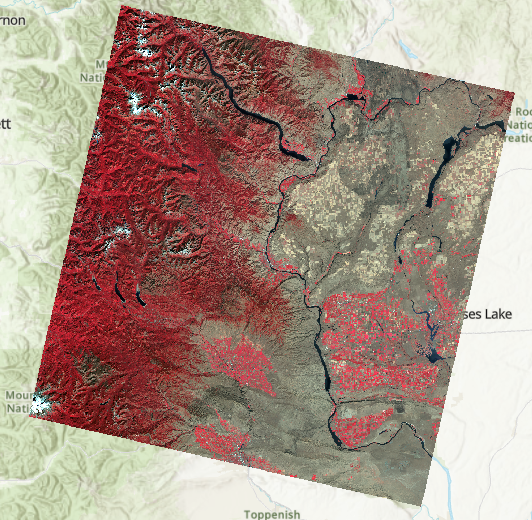

NIR false color composite (composite bands 4-3-2). Healthy vegetation appears bright red; the burn scar is the large dusky pink/tan area upper right; water is dark navy. Compare to the natural color composite above — the burn scar is now unambiguous.

**Note**

**Why does healthy vegetation appear red?**

In this composite, the NIR band is mapped to your monitor’s red channel. Living vegetation reflects extremely strongly in NIR — as much as 40–60% of incoming NIR energy is scattered upward by the spongy mesophyll tissue inside the leaf (Campbell Ch. 2). This high NIR reflectance drives the red channel on your display to high values, making healthy vegetation appear intensely red.

Burned surfaces have lost their leaf structure and pigments. Their NIR reflectance is much lower, so they produce a muted, dusky pink — you are seeing mostly the residual red and green band signal, not a strong NIR signal. Water absorbs nearly all NIR and appears very dark navy to black.

This composite is called **Color Infrared (CIR)** and has been a standard tool in vegetation and fire mapping since the 1960s (Campbell Ch. 2). The brilliant red of healthy forest versus the dull pink of the burn scar is precisely the contrast this composite was designed to reveal.

> **❓ Question 2 (Interpretation):** Compare the NIR false color composite to the natural color composite you made in Step 3.1. Identify at least two land cover types that are *easier to distinguish* in the NIR composite than in the natural color view. Explain why the NIR band makes these distinctions clearer, drawing explicitly on the concept of spectral reflectance from Campbell Ch. 2.

> **❓ Question 3 (Interpretation):** In the NIR false color composite, find an area that appears bright red and an area that appears dark or black. Use the **Identify tool** (Map tab → Explore → Identify) to click on each area and record the pixel values for composite Band 3 (Landsat B4, Red), Band 4 (Landsat B5, NIR), and Band 5 (Landsat B6, SWIR1). Present these values in a small table and explain what the difference in NIR reflectance tells you about the surface condition at each location.

### Step 3.3 — SWIR Composite for Burn Severity (Composite Bands 6-4-2 as R-G-B)

Short-wave infrared radiation penetrates atmospheric smoke and haze, and is highly sensitive to soil moisture and char. This composite is used operationally by fire agencies to map burn severity.

1. Return to **Symbology Pane**
2. Set:
   - **Red channel → Band 6** (this is Landsat B7, SWIR2, 2.11–2.29 µm)
   - **Green channel → Band 4** (this is Landsat B5, NIR, 0.85–0.88 µm)
   - **Blue channel → Band 2** (this is Landsat B3, Green, 0.53–0.59 µm)
3. Keep Stretch Type set to Percent Clip — adjust Min/Max visually as needed (0.2–1.0 is a typical range for this data)

Healthy vegetation will appear **bright green** (strong NIR signal in the green channel). The burn scar will appear as a **muted brownish area** in the upper right of the scene — less dramatic than in the CIR composite, but spatially detailed. You may be able to distinguish patches of different burn intensity within the scar. Water will appear dark navy to black.

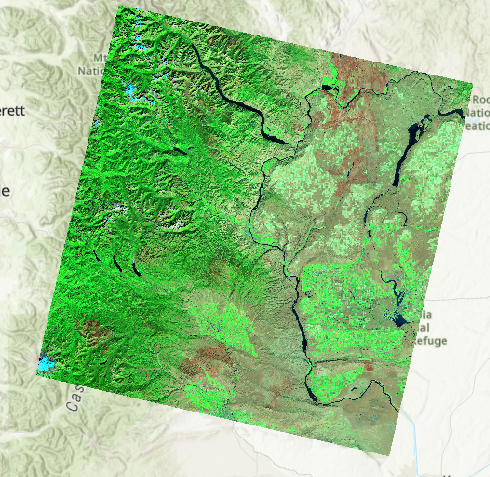

SWIR composite (composite bands 6-4-2). Vegetation is bright green; the burn scar is the muted brown area upper right; irrigated agriculture appears as bright green speckled patches in the lower right.

**Note**

**Why SWIR for burn severity?**

Charred material and exposed mineral soil have distinctly different reflectance properties than live vegetation across the shortwave infrared region. As Campbell Ch. 2 explains, different surface types produce unique spectral response patterns — and vegetation’s high water content causes it to absorb SWIR energy strongly, while burned and bare surfaces do not. This contrast in spectral response between live vegetation and fire-affected ground is precisely what makes the SWIR bands so informative for distinguishing burn severity. The SWIR2 band (2.11–2.29 µm) captures a portion of the spectrum where this separation is especially pronounced.

> **❓ Question 4 (Interpretation):** Looking at the SWIR composite, do you notice any spatial patterns within the burn scar itself — areas that appear more severely burned versus less severely burned? Describe what you observe. Based on what you have read in Campbell Ch. 2 about how different surfaces produce different spectral responses, suggest one physical reason why different parts of a burn scar might show different SWIR reflectance values.

> **📸 Screenshot 3:** Take a screenshot showing all three composites (natural color, NIR false color, SWIR) side by side, or as three sequential screenshots. Label each clearly with its band combination. Include these in your submission.

## Part 4 — Spectral Profiles

So far, you have been comparing composites visually. Now you will measure the spectral signatures of specific pixels — plotting reflectance against wavelength for individual ground locations, just as Campbell Ch. 2 describes in Figure 2.19.

### Step 4.1 — Download the Sample Point Shapefile

Download the instructor-provided shapefile `lab01_sample_points.zip` from Canvas and extract it into your Lab01 project folder. Add the shapefile to your ArcGIS Pro map (Catalog Pane → navigate to folder → drag into map).

The shapefile contains **10 sample points** representing the following cover types:

| Point ID | Cover Type | Longitude | Latitude |
| --- | --- | --- | --- |
| P1 | Dense healthy forest (unburned) | -120.692117 | 47.922775 |
| P2 | Dense healthy forest (unburned) | -121.227722 | 47.19976 |
| P3 | High-severity burn | -119.37504 | 48.099905 |
| P4 | High-severity burn | -119.573736 | 47.673221 |
| P5 | Agricultural field (dry/fallow) | -119.935169 | 47.593621 |
| P6 | Agricultural field (irrigated) | -119.755401 | 47.069682 |
| P7 | Open water (lake/pond) | -119.168659 | 47.85426 |
| P8 | Dry shrubland/rangeland | -119.688928 | 47.478636 |
| P9 | Snow | -121.103223 | 48.109005 |
| P10 | Urban | -120.508112 | 46.598891 |

**Tip**

**Can’t find the points on your map?** Right-click the sample points layer in the Contents Pane → **Zoom to Layer**. This centers the view on the extent of the point data. If points appear far from the imagery, there may be a coordinate system mismatch — check that both layers use the same projection (UTM Zone 10N).

### Step 4.2 — Create a Spectral Profile Chart

1. In the **Contents Pane**, right-click your 6-band composite layer
2. Select **Create Chart → Spectral Profile**
3. A **Chart Properties** pane will open on the right, and an empty **Spectral Profile** panel will appear at the bottom of the screen
4. Confirm the **Layer** dropdown in Chart Properties shows your composite
5. Under **Plot Type**, select **Mean Line**

### Step 4.3 — Sample Your Cover Type Locations

You will click directly on the map to collect spectral signatures at each of your 10 sample point locations. Use the `lab01_sample_points` shapefile as a visual guide — click as close to each point marker as possible.

1. In the Chart Properties pane, find the **Define an area of interest** section — you will see a row of drawing tool icons
2. Click the **Point** tool (circle icon, far left of the drawing tools)
3. Click on the map at each of your 10 sample point locations. Each click adds a new entry to the **Spectral Profiles** list in the Chart Properties pane
4. After adding each point, double-click its name in the list to **rename it** to its cover type (e.g., “Forest”, “Burnt”, “Irrigated”, etc.)
5. Click the colored square next to each entry to assign an intuitive color

**Tip**

**Getting clean samples:** Zoom in before clicking to make sure you are landing on a pure pixel of the intended cover type, not on a boundary between two types. Your sample points shapefile shows you where to click but you are sampling the raster directly — the point markers are guides, not the data source.

**Note**

**Why click manually rather than import the shapefile automatically?**

The Spectral Profile tool requires direct raster sampling. Your shapefile serves two purposes: (1) a spatial guide showing you where to click, and (2) an introduction to vector data — notice how each point has an attribute table with PointID, CoverType, and coordinate fields, just like any vector feature class. You will work extensively with vector data in later labs.

**Note**

**What to expect in your chart**

The figure below shows an instructor-generated example of what your completed spectral profile chart should look like. Your curves will differ slightly depending on exactly where you clicked, but the overall shape of each cover type should match these general patterns.

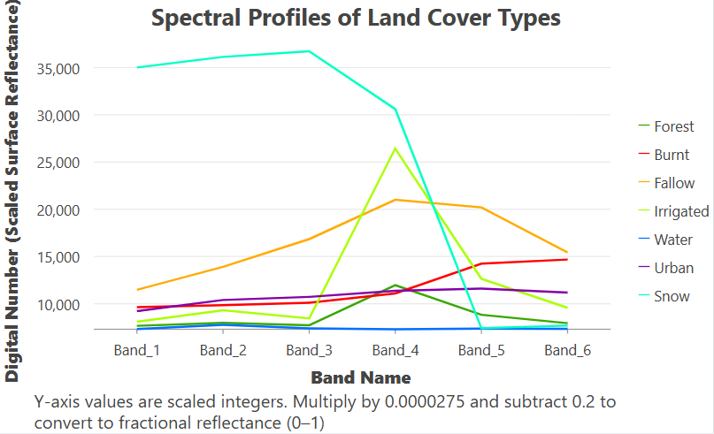

| Composite Band | Landsat Band | Wavelength | Spectral Region |
| --- | --- | --- | --- |
| 1 (B2) | Blue | 0.48 µm | Visible |
| 2 (B3) | Green | 0.56 µm | Visible |
| 3 (B4) | Red | 0.65 µm | Visible |
| 4 (B5) | NIR | 0.86 µm | Near-Infrared |
| 5 (B6) | SWIR1 | 1.61 µm | Shortwave Infrared |
| 6 (B7) | SWIR2 | 2.20 µm | Shortwave Infrared |

> **📸 Screenshot 4:** Take a screenshot of the Spectral Signature Viewer showing the spectral curves for all 10 sample points. Make sure the legend (point labels or colors) is visible. Include this in your submission.

> **❓ Question 5 (Interpretation):** Using your Spectral Signature Viewer, answer the following:
> 1. Which point(s) show the highest NIR reflectance (Band 4)? What land cover does this represent, and why does this surface have such high NIR reflectance? (Reference Campbell Ch. 2.)
> 2. Which point(s) show the lowest NIR reflectance? What does this tell you about those surfaces?
> 3. Snow (P9) has very high reflectance in both visible AND NIR bands, but drops sharply in SWIR (Bands 5–6). Healthy vegetation also has high NIR reflectance. Based on your chart, which band(s) best separate snow from healthy vegetation, and why might this matter for remote sensing applications in mountainous or high-latitude environments?
> 4. Urban (P10) and dry shrubland (P8) may look similar in natural color. Do their spectral profiles help separate them? Which bands are most diagnostic?

> **❓ Question 6 (Interpretation):** Campbell Ch. 2 introduces the idea of a **spectral signature** — the concept that different surface types produce distinctive patterns of reflectance across wavelengths. Looking at your spectral profile chart, do the 10 sample points produce clearly distinct signatures, or do some cover types have similar spectral patterns?

> Identify one pair of cover types that would be **difficult to distinguish** using only the visible bands (Bands 1–3), and explain why adding NIR and SWIR bands helps separate them.

**Note**

**A note on spatial resolution and spectral profiles**

The Spectral Profile tool samples a *single pixel* at each location you click. At 30-meter Landsat resolution, that one pixel represents a 30 × 30 m patch of ground. For at least two of your sample points — especially any that fall near the edge of the burn scar, a forest boundary, or an agricultural field — consider how this resolution constraint may affect what you are reading. Is the pixel you sampled likely to contain a pure example of that cover type, or a mix of two or more types? How would your spectral profile change if the sensor’s resolution were 10 m (like Sentinel-2’s visible bands) instead of 30 m? Incorporate your answer into your response to Question 6.

## Part 5 — Map Layout and Export

The final task is to produce a cartographically complete map of the Pearl Hill burn scar. A cartographically complete map is one that another person can read and interpret without your help — it carries everything they need to understand what they are looking at, where it is, and at what scale.

Your map does not need to look like the instructor example below. It should reflect your own cartographic judgment about how to best communicate this particular scene. The instructor example is provided so you can see what the elements look like in practice, not as a template to replicate.

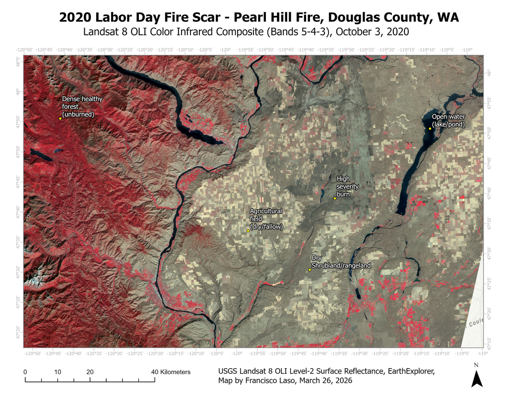

**Instructor example.** One possible finished layout for this lab. Your map should serve the same communicative function but does not need to match this arrangement, scale, or style.

### Step 5.1 — Create a New Layout

1. In the ribbon, go to **Insert tab → New Layout** (click the dropdown arrow below “New Layout”)
2. Under **ANSI — Landscape**, select **Letter (8.5 × 11 in)**
3. A new **Layout** tab will open alongside your Map tab

**Note**

Layouts in ArcGIS Pro are separate from your map — they are print/export canvases that *reference* your map view. Any changes you make to the map (symbology, zoom level) will update automatically in the layout. You can switch between the Map tab and Layout tab at any time.

### Step 5.2 — Add the Map Frame and Set Your Extent

1. With the **Layout tab active**, go to **Insert tab → Map Frame**
2. Click and drag on the white canvas to draw a rectangle for your map
3. Double-click inside the frame to activate it, then pan and zoom to center on and highlight the **burn scar** — this is your subject, and it should dominate the frame
4. Click outside the frame to deactivate when you are satisfied with the extent

**Tip**

**The extent is a cartographic decision.** How much context do you need to show? Enough that a reader can place the burn scar geographically, but not so much that it becomes a small feature in a large empty scene. There is no single correct zoom level — use your judgment.

**Warning**

**ArcGIS Pro can freeze during layout operations** with large rasters loaded. If the application becomes unresponsive, wait 2–3 minutes before force-closing. To reduce the risk, zoom your map view to the desired extent *before* creating the layout.

### Step 5.3 — Confirm the Band Combination

Make sure your map is displaying the **NIR false color composite (composite bands 4-3-2)**. The layout reflects whatever is currently displayed in the map view — switch to the Map tab to adjust symbology if needed.

### Step 5.4 — Required Map Elements

Every map you produce in this course must include the elements below. For each one, the rationale is explained so you understand *why* it is required — use that understanding to make your own decisions about placement, size, and style.

**Title**

*Why:* A map without a title forces the reader to guess what they are looking at. The title should answer: what is this a map of, where, with what data, and when?

*How:* **Insert tab → Text**. Click anywhere on the canvas and type. To edit after placing: double-click the text element. To change font size or style: select the element → **Format tab → Text Symbol**.

*Your choice:* Write a title that accurately describes this map. Include the event name, location, sensor, band combination, and date. Make it large enough to read clearly. Place it where it does not compete with the map content.

**North Arrow**

*Why:* Establishes map orientation for the reader. Essential whenever north is not self-evident.

*How:* **Insert tab → North Arrow**. A style gallery appears — choose any style that reads clearly. Click to place, drag corner handles to resize.

*Your choice:* Size and placement are yours to decide. The convention is unobtrusive — a north arrow that competes with the map data is too large.

**Scale Bar**

*Why:* Allows the reader to estimate real-world distances from the map. A map without a scale bar is dimensionless.

*How:* **Insert tab → Scale Bar**. Choose a style. Double-click after placing to open properties and set division units and values.

*Your choice:* Choose a scale bar span and interval that is appropriate for your map extent — the right answer depends on how far you are zoomed in. The one non-negotiable: **scale bars must be in kilometers (SI units), not miles.** Remote sensing and geographic science use metric units universally. If the scale bar shows “unknown units,” check your coordinate system (UTM Zone 10N).

**Coordinate Grid**

*Why:* Provides geographic reference so the reader knows exactly where on Earth this map is located.

*How:* Double-click the map frame to activate it → right-click → **Properties → Grids tab → Add Grid → Graticule**. Expand the graticule settings to set the interval and label options.

*Your choice:* Choose a grid interval that produces readable, well-spaced lines for your map extent. Labels should be legible but small enough not to clutter the map.

**Band Combination Key**

*Why:* Unlike a standard photograph, a false color composite requires explanation — the reader cannot intuit what the colors mean. A key tells them which bands are displayed and what the major color classes represent.

*How:* **Insert tab → Text**. Type a brief key directly on the layout — there is no automated tool for this since the composite has no classified symbology.

*Your choice:* What does the reader need to know to interpret the colors in your specific map? At minimum: which bands are shown (e.g., NIR–Red–Green as R–G–B) and what the dominant color patterns mean (e.g., bright red = healthy vegetation).

**Data Source Credit**

*Why:* Scientific and professional maps always cite their data source. This allows the reader to verify, reproduce, or extend the work.

*How:* **Insert tab → Text**. Place it in a margin area — typically small text, unobtrusive.

*Your choice:* Include the sensor, product level, and source at minimum (e.g., “USGS Landsat 8 OLI Level-2 Surface Reflectance, EarthExplorer”).

**Author Name and Date**

*Why:* Establishes accountability and documents when the map was made.

*How:* **Insert tab → Text**. Place in any margin.

### Step 5.5 — Review Before Exporting

Before exporting, step back and ask: **does this map clearly communicate the Pearl Hill burn scar?** A reader who knows nothing about this fire should be able to find the burn scar, understand what the colors mean, and know where they are geographically.

Common issues to check:

- Does the burn scar actually fill a meaningful portion of the frame, or is it a small feature lost in a large scene?
- Can all text (title, labels, scale bar units) be read at normal viewing distance?
- Does the band combination key explain what the reader is actually seeing?
- Is the scale bar in kilometers?

### Step 5.6 — Export to PDF

1. **Share tab → Export Layout**
2. Set **File Type** to **PDF**
3. Set **Resolution** to **300 dpi**
4. Name the file `Lab01_Map_YourLastName.pdf`
5. Export to your Lab01 folder

## Standard Operating Procedure (SOP)

Complete this section **in your own words** as you work through the lab. Your SOP is a replicable procedure document — someone else should be able to follow it to reproduce your exact result. Write it as if addressing a technically competent colleague who has never done this specific task.

### 1. Objective

*In 2–4 sentences, state the scientific purpose of this analysis. What environmental question are you investigating, and what does the Landsat 8 imagery allow you to observe that other methods would not?*

### 2. Data Inventory

*List each data source used, following this format:*

| Dataset | Source | Acquisition Date | Spatial Resolution | Spectral Bands Used |
| --- | --- | --- | --- | --- |
| Landsat 8 or 9 OLI L2 SR | USGS EarthExplorer | [your date] | 30 m | B2, B3, B4, B5, B6, B7 |
| Sample Points (lab01_sample_points) | Instructor-provided | 2026 | N/A | N/A |

### 3. SOP — The Workflow

*Write a numbered, step-by-step account of your workflow. This should be detailed enough that another student could reproduce your analysis exactly.*

*At minimum, cover: (1) EarthExplorer scene search and filter criteria, (2) how you assembled the composite, (3) how you set each band combination, (4) how you used the Spectral Profile chart.*

### 4. Results and Visual Evidence

*In 3–5 sentences, summarize the key visual and spectral patterns you observed. Which band combination was most useful for identifying the burn scar? What did the spectral profiles reveal about the difference between burned and unburned surfaces?*

### 5. Analyst’s Note

*Identify at least **two** limitations of this analysis. These should be methodological or data-related limitations — not personal difficulties with the software.*

*Examples of the kinds of limitations to consider (do not simply copy these; write your own):* - *Temporal gap between fire event and image acquisition* - *Spatial resolution constraints and mixed pixels* - *Atmospheric correction assumptions in Level-2 data* - *Single-date analysis versus temporal comparison*

## Submission Checklist

Compile the following into a single PDF or Word document and submit to Canvas before the next class session:

- **Screenshot 1** — EarthExplorer scene selection
- **Screenshot 2** — ArcGIS Pro with coordinate system properties
- **Screenshot 3** — All three composites (natural color, NIR, SWIR)
- **Screenshot 4** — Spectral Signature Viewer with all 10 points
- **Exported PDF map** (`Lab01_Map_YourLastName.pdf`) — submitted separately. The map must include: a descriptive title, north arrow, scale bar in kilometers, coordinate grid, band combination key, data source credit, and your name/date. The burn scar should be clearly visible and the dominant feature of the frame.
- **Answers to Questions 1–6** (inline with your document)
- **Completed SOP** (all five sections filled in)

**Note**

**Grading Note**

This lab is graded as a **Weekly Methods Log (SOP)**. Your SOP sections carry the most weight. Interpretation questions are assessed on demonstrated connection to the assigned readings — vague answers that do not reference specific concepts from Campbell Ch. 1 or Ch. 2 will receive partial credit. Screenshots are checked for completeness, not aesthetic quality. The exported PDF map is the primary visual deliverable.

*ESCI 442/542 — Introduction to Remote Sensing | Western Washington University | Last updated: April 2026*